# 1 Jogo *Craps*

## 1.1 Objetivo

Apresentar aos visitantes da mostra o jogo *Craps* e por via dele estimular o pensamento probabilístico dos mesmos.

## 1.2 Descrição

O jogo funciona da seguinte maneira: O participante joga dois dados, se o total das faces superiores for igual a 7 ou 11 ele ganha, caso igual a 2, 3 ou 12 ele perde, resultados diferentes se tornam “ponto” nesse caso o participante deve continuar jogando os dados até que apareçam o “ponto” onde ele ganha ou o 7 onde ele perde.

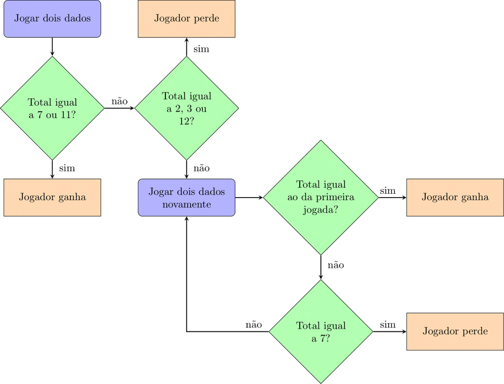

Figure 1.1: Diagrama de fluxo para o jogo Craps

## 1.3 Construção

São necessarios apenas dois dados.

## 1.4 Execução

Repetir o algoritmo retratado na imagem 1.1 com cada participante e ao final explicar de maneira que achar apropriada o comportamento probabilístico do jogo.

## 1.5 Teoria

### 1.5.1 Comportamento do total em um lançamento de dois dados

Assumindo que ambos os dados sejam honestos temos que todos os possíveis pares de resultados são equiprováveis, ou seja, possuem a mesma chance de ocorrência, logo podemos utilizar a ideia clássica de probabilidade, casos favoráveis sobre casos possíveis, para encontrar a chance de cada resultado ocorrer.

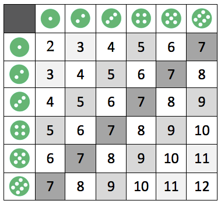

Figure 1.2: Possiveis totais decorrentes do lançamento de dois dados

Admita $X$ sendo a variável aleatória que representa o total das faces superiores no experimento “lançar dois dados honestos e observar seus resultados”, com espaço amostral associado $\Omega = \{2,3,4,5,6,7,8,9,10,11,12\}$, temos:

$$P(X = x) = \frac{\text{resultados em que o total é }x}{\text{ resultados possiveis}}, \quad \forall \:x \in \Omega.$$
Calculando as probabilidades para cada $x \in \Omega$ obtemos a seguinte tabela:

| $x$ | 2 | 3 | 4 | 5 | 6 | 7 | 8 | 9 | 10 | 11 | 12 |
| --- | --- | --- | --- | --- | --- | --- | --- | --- | --- | --- | --- |
| $P(X = x)$ | $\frac{1}{36}$ | $\frac{2}{36}$ | $\frac{3}{36}$ | $\frac{4}{36}$ | $\frac{5}{36}$ | $\frac{6}{36}$ | $\frac{5}{36}$ | $\frac{4}{36}$ | $\frac{3}{36}$ | $\frac{2}{36}$ | $\frac{1}{36}$ |

### 1.5.2 Probabilidade de vitória em *Craps*

Sendo $X_1$ o total do primeiro lançamento temos o seguinte, cada possível resultado de $X_1$ possui uma certa probabilidade de vitória associada a ele, por exemplo quando $X_1=2$ a probabilidade de vitória é 0 e quando $X_1=11$ a probabilidade de vitória é 1, utilizando a linguagem de probabilidade condicional e denotando por $v$ o evento “vitória para o jogador”, temos:

$$\begin{align*}
P(v\mid X_1=7)&=1 & P(v\mid X_1=11)&=1 \\
P(v\mid X_1=2)&=0 & P(v\mid X_1=12)&=0 \\
P(v\mid X_1=3)&=0 &
\end{align*}$$

Para os resultados que se tornam “ponto”, $\{4,5,6,8,9,10\}$, a probabilidade de vitória é um pouco mais complicada de ser calculada.

Considere por exemplo o resultado $X_1 = 9$ onde o participante deve continuar jogando os dados até que apareçam o total 9 onde ele ganha ou o total 7 onde ele perde.

Nesse caso em especifico ele ganha com probabilidade $\frac{4}{36}$, perde com probabilidade $\frac{6}{36}$ e joga novamente com probabilidade $\frac{26}{36}$, contudo esses valores são verdadeiros somente quando olhamos para cada jogada de forma independente, por exemplo a probabilidade de vitória na segunda jogada é de $\frac{4}{36} \frac{26}{36}$ pois para realizar a segunda tentativa o participante teve que ter tirado um valor diferente de 9 e 7 na primeira, generalizando esse resultado obtemos que a probabilidade de vitória na n-ésima jogada é de $\frac{4}{36} \left(\frac{26}{36}\right)^n$.

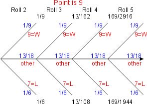

Figure 1.3: Alguns dos possíveis resultados caso o ponto seja 9

Sabendo disso podemos escrever a probabilidade de vitória dado que $X_1=9$ da seguinte forma:

$$P(v \mid X_1=9) = \frac{4}{36} + \frac{4}{36} \frac{26}{36} + \frac{4}{36}\left(\frac{26}{36}\right)^2+\dots \;= \sum_{n=0}^\infty \frac{4}{36} \left(\frac{26}{36}\right)^n$$

$$\sum_{n=0}^\infty \frac{4}{36} \left(\frac{26}{36}\right)^n = \frac{\frac{4}{36}}{1-\frac{26}{36}}=\frac{4}{10}$$
Por fim

$$P(v \mid X_1=9)=\frac{4}{10}$$

Replicando esse cálculo para os outros valores de $X_1$ que resultam “ponto” obtemos a seguinte tabela:

| $x$ | 2 | 3 | 4 | 5 | 6 | 7 | 8 | 9 | 10 | 11 | 12 |
| --- | --- | --- | --- | --- | --- | --- | --- | --- | --- | --- | --- |
| $P(v \mid X_i = x)$ | 0 | 0 | $\frac{3}{9}$ | $\frac{4}{10}$ | $\frac{5}{11}$ | 1 | $\frac{5}{11}$ | $\frac{4}{10}$ | $\frac{3}{9}$ | 1 | 0 |

Como os resultados de $X_1$ são mutualmente excludentes podemos utilizar o teorema da probabilidade total para encontrar a probabilidade de $v$:

$$P(v) = \sum_{x \in \Omega} P(v \mid X_1=x)P(X_1=x)$$
Logo

$$P(v) = 0\frac{1}{36} + 0\frac{2}{36} + \frac{3}{9}\frac{3}{36} + \frac{4}{10}\frac{4}{36} + \dots + 1\frac{2}{36} + 0\frac{1}{36} = \frac{244}{495} \approx 0.4929$$

### 1.5.3 Simulaçao de 10000 jogos de Craps em *R*

```r
somar_dois_dados = function(){
  d = sample(c(1,2,3,4,5,6), 2, replace = T)
  return(sum(d))
}

craps = function(){
  d1 = somar_dois_dados()
  if (d1 == 7 | d1 == 11){
    return("V")
  } else {
    if (d1 == 2 | d1 == 3 | d1 == 12){
      return("D")
    } else {
      return(d1)
    }
  }
}

n = 0; v = 0; d = 0

while (n < 10000){
  primeira_jogada = craps()
  if (primeira_jogada == "V"){
    v = v + 1
    n = n + 1
  } else {
    if (primeira_jogada == "D"){
      d = d + 1
      n = n + 1
    } else {
      while(TRUE){
        nova_jogada = somar_dois_dados()
        if (primeira_jogada == nova_jogada){
          v = v + 1
          n = n + 1
          break
          } else {
            if (nova_jogada == 7){
              d = d + 1
              n = n + 1
              break
          }
        }
      }
    }
  }
}
sprintf("O jogador ganhou %d das %d partidas", v, n )
```

```
[1] "O jogador ganhou 4921 das 10000 partidas"
```

## 1.6 Referencias

**James Jones**. “Craps”, disponível em: https://people.richland.edu/james/ictcm/2002/craps.html